# Juzgamiento de hipótesis

# Tipos de Hipótesis

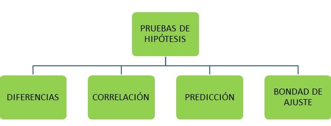

# Bondad de ajuste.

**Hipótesis Nula**

$H_{0}: F(x) = F_{0}(x)$ los datos se ajustan a una distribución dada, la cual puede ser la distribución normal.

**Hipótesis Alternativa**

$H_{a}: F(x) \not= F_{0}(x)$ los datos **NO** se ajustan a una distribución dada, la cual puede ser la distribución normal.

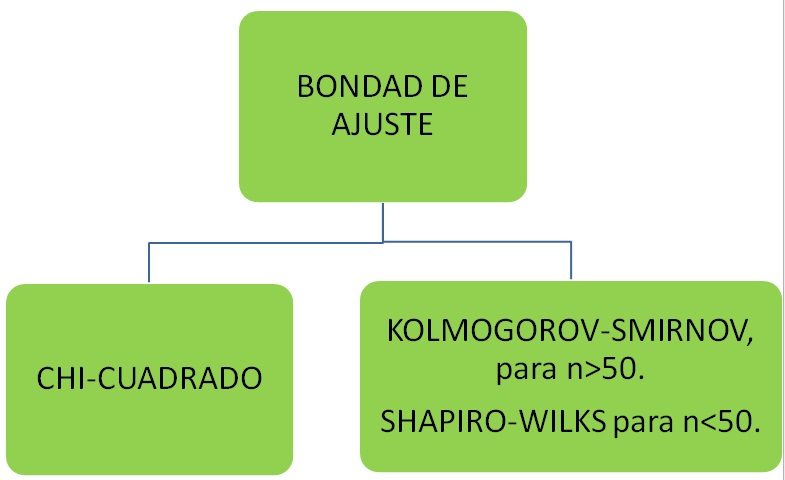

# Homocedasticidad

**Hipótesis Nula**

$H_{0}: \frac{\sigma_{1}}{\sigma_{2}} = 1$ las varianzas poblacionales son iguales.

**Hipótesis Alternativa**

$H_{a}: \frac{\sigma_{1}}{\sigma_{2}} \not= 1$ las varianzas poblacionales NO son iguales.

**Prueba de Leven**

# Estadística Parámetrica y no parámetrica

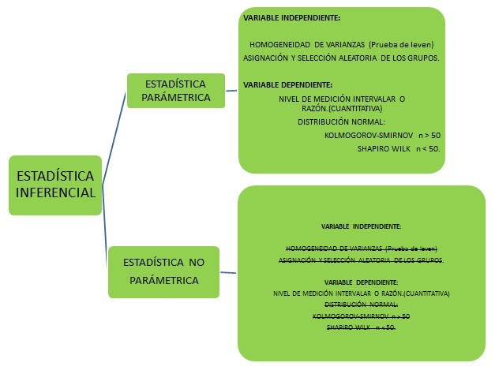

# Pruebas de hipótesis comparativas(diferencias).

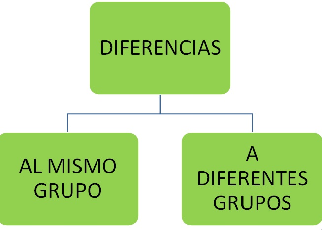

# Diferencias en el mismo grupo.

**CASO I**

**Hipótesis Nula**

$H_{0}: \mu_{1}=\mu_{2}$ las medias son iguales.

**Hipótesis alternativa**

$H_{a}: \mu_{1}\not=\mu_{2}$ las medias son diferentes.

**CASO II**

**Hipótesis Nula**

$H_{0}: \mu_{1}\leq\mu_{2}$ la media uno es menor o igual a la media dos.

**Hipótesis alternativa**

$H_{a}: \mu_{1} >\mu_{2}$ la media uno es mayor a la media dos.

**CASO III**

**Hipótesis Nula**

$H_{0}: \mu_{1}\geq\mu_{2}$ la media uno es mayor o igual a la media dos.

**Hipótesis alternativa**

$H_{a}: \mu_{1}<\mu_{2}$ la media uno es menor a la media dos.

# Diferencias en el mismo grupo.

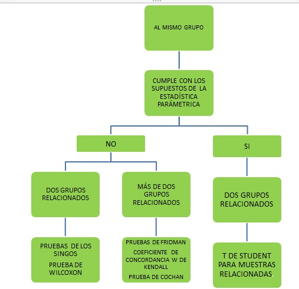

# Diferencias en diferentes grupos.

**DOS GRUPOS**

**CASO I**

**Hipótesis Nula**

$H_{0}: \mu_{1}=\mu_{2}$ las medias son iguales.

**Hipótesis alternativa**

$H_{a}: \mu_{1}\not=\mu_{2}$ las medias son diferentes.

**CASO II**

**Hipótesis Nula**

$H_{0}: \mu_{1}\leq\mu_{2}$ la media uno es menor o igual a la media dos.

**Hipótesis alternativa**

$H_{a}: \mu_{1} >\mu_{2}$ la media uno es mayor a la media dos.

**CASO III**

**Hipótesis Nula**

$H_{0}: \mu_{1}\geq\mu_{2}$ la media uno es mayor o igual a la media dos.

**Hipótesis alternativa**

$H_{a}: \mu_{1}<\mu_{2}$ la media uno es menor a la media dos.

**MÁS DE DOS GRUPOS**

**Hipótesis Nula**

$H_{0}: \mu_{1}=\mu_{2} = \dots \mu_{k}$ las medias son iguales en todos los grupos.

**Hipótesis alternativa**

$H_{a}: \mu_{i}\not=\mu_{j}$, para $i,j= 1,2,...,k,$ con $i\not=j.$ existe por lo menos una media diferente.

# Ejemplo

The purpose of an investigation by Morley et al. (A-17) was to evaluate the analgesic effectiveness of a daily dose of oral methadone in patients with chronic neuropathic pain syndromes. The researchers used a visual analogue scale (0–100 mm, higher number indicates higher pain) ratings for maximum pain intensity over the course of the day. Each subject took either 20 mg of methadone or a placebo each day for 5 days. Subjects did not know which treatment they were taking. The following table gives the mean maximum pain intensity scores for the 5 days on methadone and the 5 days on placebo. Do these data provide sufficient evidence, at the .05 level of significance, to indicate that in general the maximum pain intensity is lower on days when methadone is taken?

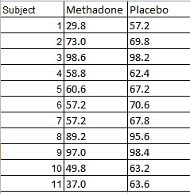

**Hipótesis Nula**

$H_{0}: \mu_{1}=\mu_{2}$ El dolor promedio neuropático son iguales tomado methadona o tomando placebo.

**Hipótesis alternativa**

$H_{a}: \mu_{1}\not=\mu_{2}$, El dolor promedio neuropático es diferente(o menor) tomado methadona o tomando placebo.

# Salida de Spss

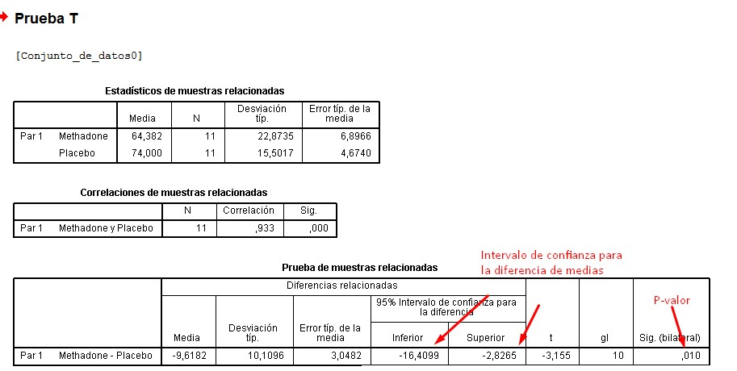

# Diferencias en diferentes grupos.

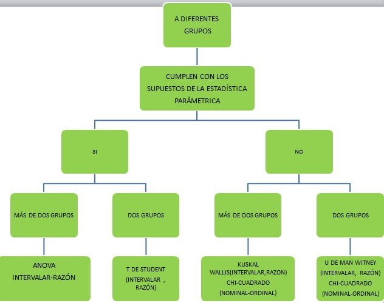

# Ejemplo para dos grupos, muestras independientes

Can we conclude that, on the average, lymphocytes and tumor cells differ in size? The following are the cell diameters ð Þ mm of 40 lymphocytes and 50 tumor cells obtained from biopsies of tissue from patients with melanoma:

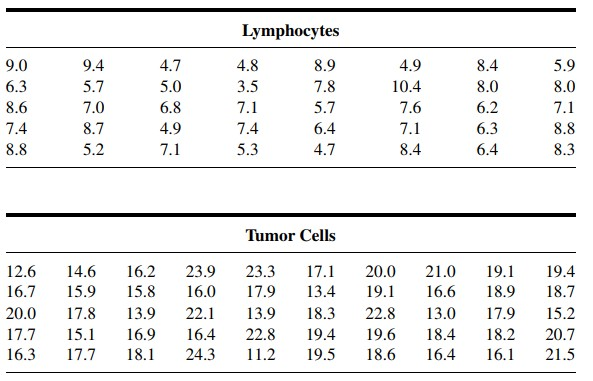

# Hiótesis

**Hipótesis Nula**

$H_{0}: \mu_{1}=\mu_{2}$ El diametro promedio de los lymphocytes y las celulas tumorales son iguales. **Hipótesis alternativa**

$H_{a}: \mu_{1}\not=\mu_{2}$, El diametro promedio de los lymphocytes y las celulas tumorales son diferentes.

# Ejemplo dos muestras independientes

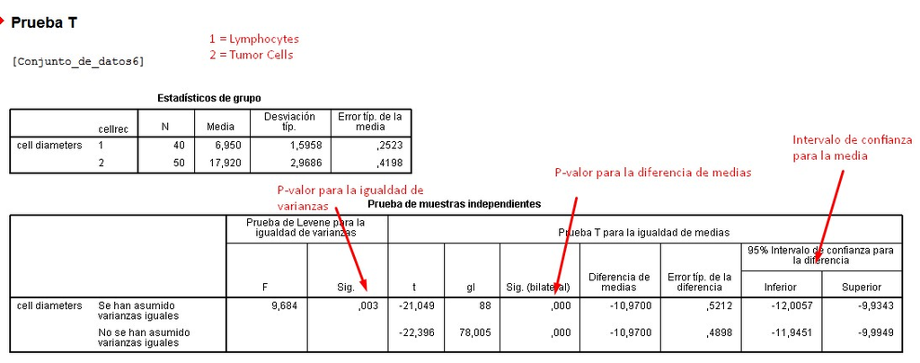

# Ejemplo para más de dos grupos (ANOVA)

A remotivation team in a psychiatric hospital conducted an experiment to compare five methods for remotivating patients. Patients were grouped according to level of initial motivation. Patients in each group were randomly assigned to the five methods. At the end of the experimental period the patients were evaluated by a team composed of a psychiatrist, a psychologist, a nurse, and a social worker, none of whom was aware of the method to which patients had been assigned. The team assigned each patient a composite score as a measure of his or her level of motivation. The results were as follows:

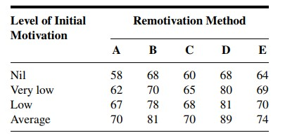

# Hipótesis para el Anova

**Hipótesis Nula**

$H_{0}: \mu_{1}=\mu_{2} =\mu_{3} =\mu_{4} =\mu_{5}$ los promedios de remotivación de todos los métodos son iguales en todos los grupos.

**Hipótesis alternativa**

$H_{a}: \mu_{i}\not=\mu_{j}$, para $i,j= 1,2,...,k,$ con $i\not=j.$ existe por lo menos un promedio de remotivación de un tratamiento es diferente.

# Salida de SPSS

[figure not shown]

# Correlación.

**Hipótesis Nula**

$H_{0}: r_{xy}=0$ no existe correlación entre $x$ e $y$ (son independientes).

**Hipótesis alternativa**

$H_{0}: r_{xy}\not=0$ existe correlación entre $x$ e $y$.

# Correlación.

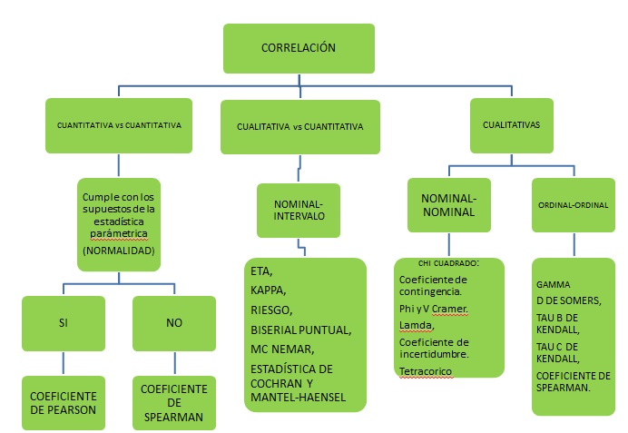

# Ejemplo correlación (Cualitativa-Cualitativa)

**Hipótesis Nula**

$H_{0}: r_{xy}=0$ no existe correlación entre el grupo sanguineo e el factor RH (son independientes).

**Hipótesis alternativa**

$H_{0}: r_{xy}\not=0$ existe correlación entre el grupo sanguineo e el factor RH

# Salida SPSS

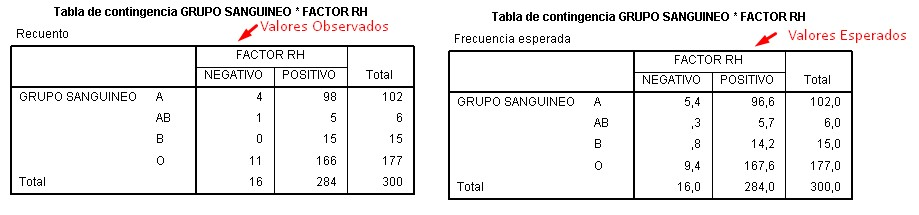

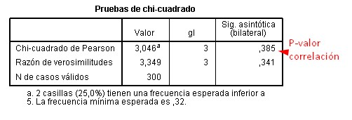

# Ejemplo correlación(Cuantitativa - Cuantitativa)

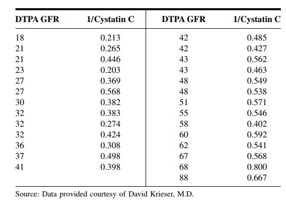

# Hipótesis

**Hipótesis Nula**

$H_{0}: r_{xy}=0$ no existe correlación entre DTPA GFR y 1/Cystatin_C (son independientes).

**Hipótesis alternativa**

# Diagrama de puntos

# Nube de puntos

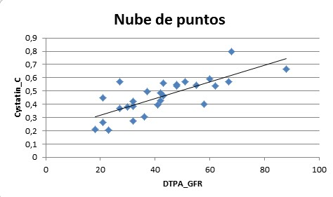

# Salida de SPSS

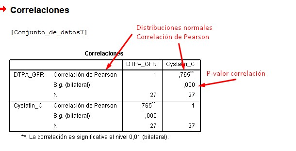

# Predicción.

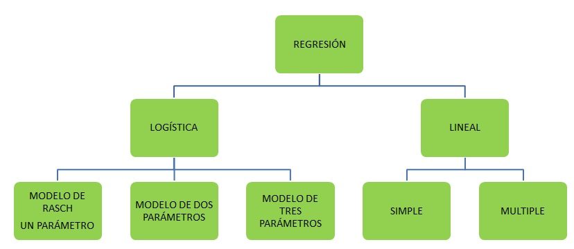

# Modelo de predicción regresión lineal simple

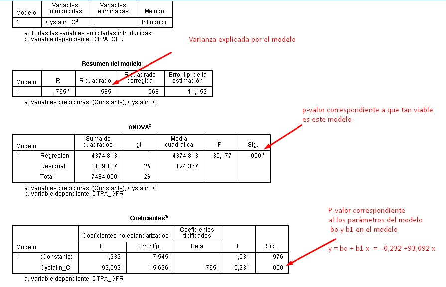